# HyDaP algorithm in R

Shu Wang

#### This is a brief tutorial of using the HyDaP algorithm to cluster mixed data. Three simulated data sets that represent three data structures are generated first. Then we analyze each of them to obtain final clustering results.

## Three Working Data Sets

```r
dat<- list(data1, data2, data3)

lapply(dat, dim)
```

```
## [[1]]
## [1] 200   5
##
## [[2]]
## [1] 200  14
##
## [[3]]
## [1] 200   7
```

```r
lapply(dat, summary)
```

```
## [[1]]
##        x1                x2              x3                x4           x5
##  Min.   :-7.4977   Min.   :14.23   Min.   :-8.5779   Min.   :-2.81789   0: 48
##  1st Qu.: 0.6827   1st Qu.:17.91   1st Qu.:-0.6469   1st Qu.:-0.68795   1: 50
##  Median : 4.3953   Median :19.06   Median : 3.1827   Median : 0.06250   2:102
##  Mean   : 3.5734   Mean   :19.88   Mean   : 1.0531   Mean   :-0.04922
##  3rd Qu.: 6.4950   3rd Qu.:20.75   3rd Qu.: 4.2886   3rd Qu.: 0.62000
##  Max.   : 9.9319   Max.   :27.59   Max.   : 6.6156   Max.   : 2.99029
##
## [[2]]
##        x1                x2              x3               x4
##  Min.   :-7.4977   Min.   :17.23   Min.   : 3.178   Min.   :-2.81789
##  1st Qu.:-1.9728   1st Qu.:20.27   1st Qu.: 5.983   1st Qu.:-0.68795
##  Median :-0.6241   Median :21.32   Median : 6.970   Median : 0.06250
##  Mean   :-0.6266   Mean   :21.48   Mean   : 6.853   Mean   :-0.04922
##  3rd Qu.: 0.9104   3rd Qu.:22.41   3rd Qu.: 7.687   3rd Qu.: 0.62000
##  Max.   : 3.9319   Max.   :26.59   Max.   :10.076   Max.   : 2.99029
##        x5              x6                 x7                 x8
##  Min.   :36.80   Min.   :-2.84542   Min.   :-2.86019   Min.   :-2.527855
##  1st Qu.:39.36   1st Qu.:-0.61746   1st Qu.:-0.77526   1st Qu.:-0.766061
##  Median :39.94   Median : 0.12398   Median :-0.04669   Median :-0.030096
##  Mean   :39.98   Mean   : 0.08127   Mean   :-0.04043   Mean   : 0.002042
##  3rd Qu.:40.54   3rd Qu.: 0.79812   3rd Qu.: 0.69610   3rd Qu.: 0.719026
##  Max.   :42.55   Max.   : 3.26457   Max.   : 2.84095   Max.   : 3.595376
##        x9               x10               x11          x12    x13     x14
##  Min.   :-4.5979   Min.   :-2.4043   Min.   :-1.9494   0:61   4: 48   0:110
##  1st Qu.:-2.4559   1st Qu.:-0.3121   1st Qu.:-0.2430   1:74   5: 40   1: 41
##  Median :-1.6494   Median : 1.2281   Median : 0.4392   2:65   6:112   2: 49
##  Mean   :-1.3043   Mean   : 1.0216   Mean   : 0.6146
##  3rd Qu.:-0.1434   3rd Qu.: 2.2652   3rd Qu.: 1.3396
##  Max.   : 2.8586   Max.   : 4.3892   Max.   : 4.1195
##
## [[3]]
##        x1                  x2                x3                x4
##  Min.   :-1.374434   Min.   :-6.7658   Min.   :-0.2112   Min.   :-2.81789
##  1st Qu.:-0.334501   1st Qu.:-3.5760   1st Qu.: 2.7062   1st Qu.:-0.68795
##  Median : 0.015412   Median :-2.8615   Median : 4.2401   Median : 0.06250
##  Mean   :-0.006645   Mean   :-2.9152   Mean   : 4.1062   Mean   :-0.04922
##  3rd Qu.: 0.389974   3rd Qu.:-2.2508   3rd Qu.: 5.2313   3rd Qu.: 0.62000
##  Max.   : 1.251323   Max.   :-0.3211   Max.   : 9.2312   Max.   : 2.99029
##  x5      x6     x7
##  0:110   0:54   4: 40
##  1: 45   1:77   5: 43
##  2: 45   2:69   6:117
##
##
##
```

#### Each simulated data set contains 200 observations. Data 1 is consists of 4 continuous variables and 1 categorical variable. Data 2 is consists of 11 continuous variables and 3 categorical variables. Data 3 is consists of 4 continuous variables and 3 categorical variables. Three clusters exist in each of these data sets.

## Step 1 Data Structure Identification and Variable Selection

### Run OPTICS on continuous variables to obtain a reachability plot

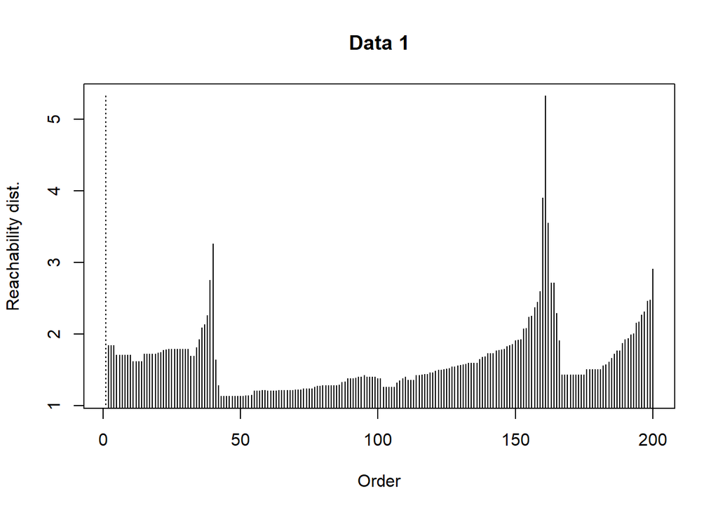

```r
op<- optics(data1[,1:4],eps = 10,minPts = 10) # relative larger eps and minPts

plot(op, main='Data 1')
```

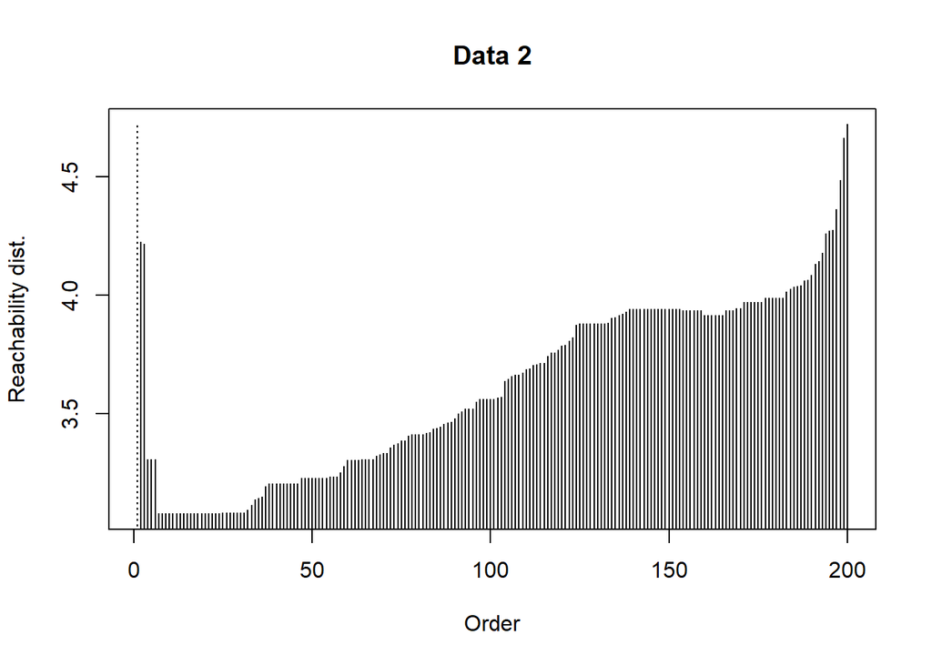

```r
op<- optics(data2[,1:11],eps = 10,minPts = 20) # relative larger eps and minPts

plot(op, main='Data 2')
```

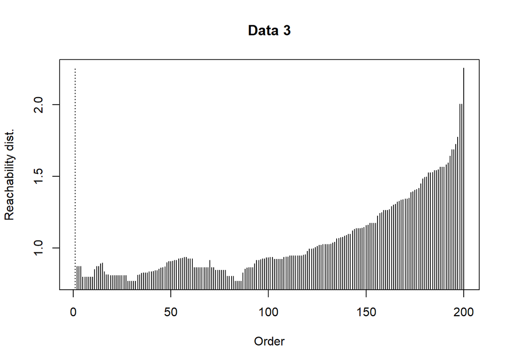

```r
op<- optics(data3[,1:4],eps = 10,minPts = 10) # relative larger eps and minPts

plot(op, main='Data 3')
```

#### From 3 reachability plot we can observe that only data 1 displays 3 "vallies" indicating that data 1 belongs to *natural cluster structure*. Data 2 and 3 belongs to *partitioned cluster structure* or *homogeneous structure*.

### Run Sparse k-means for data 1 and consensus k-means for data 2 and 3

```r
data_run<- scale(data1[,-5],T,T) # scale is recommended

tune<- KMeansSparseCluster.permute(as.matrix(data_run),K=3,wbounds=seq(1.1, 3.1, by=0.3),silent = T)

sparsek<- KMeansSparseCluster(as.matrix(data_run),K=3,wbounds = tune$bestw,silent = T)

sparsek[1][[1]]$ws
```

```
##          x1          x2          x3          x4
## 0.491210566 0.586567459 0.643931423 0.001765776
```

```r
cramer.v(table(data1$x5,sparsek[1][[1]]$Cs))
```

```
## [1] 0.6757008
```

#### From obtained weights, it's not that hard to drop variable $x_4$. Based on the cramer's V between variable $x_5$ and sparse k-means clustering assignment, $x_5$ will be kept. Therefore, $x_1$, $x_2$, $x_3$, and $x_5$ will be kept in final clustering step.

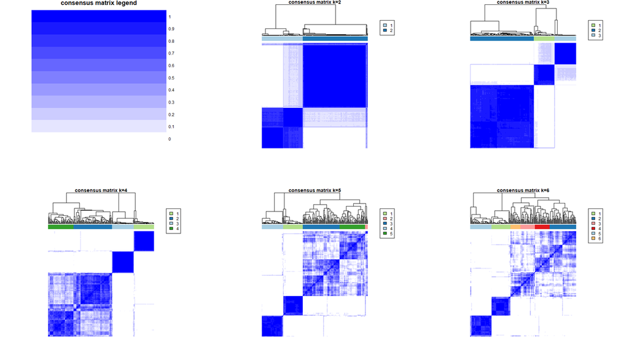

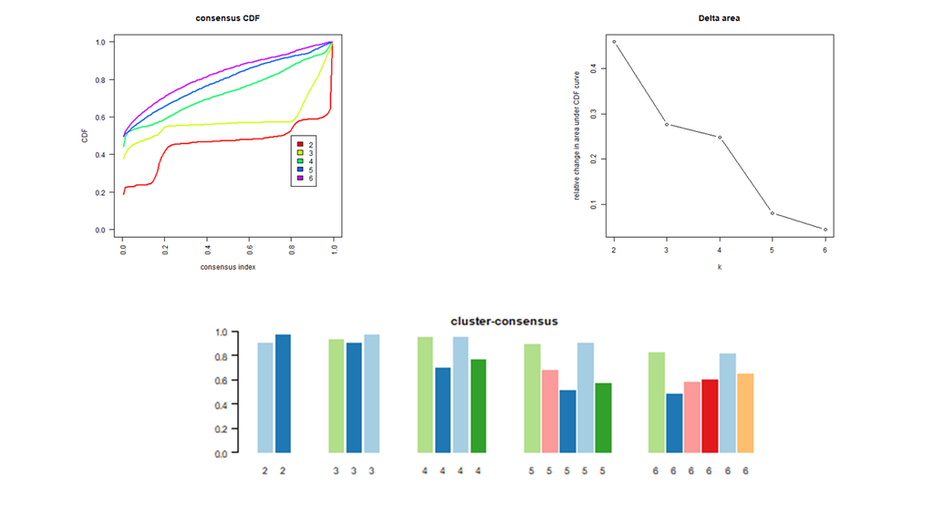

```r
data2.new<- t(scale(data2[,1:11],T,T))

results.dat2<-  ConsensusClusterPlus(as.matrix(data2.new),maxK=6,reps=1000,pItem=0.8,pFeature=1,
                               clusterAlg="km",distance="euclidean",seed=1262,plot='png',
                               title=paste0(path,'/hydapDat2'))

#results2.dat2<- calcICL(results.dat2, plot='png',title=paste0(path,'/hydapDat2'))
```

#### From consensus k-means results of data 2, we can observe that 3 is the optimal number of clusters. As we are able to partition the continuous part of data 2, it is defined as *partitioned cluster structure*. Therefore, we will keep all continuous variables in final clustering as all of them together lead to partitions.

```r
apply(data2[,12:14],2, function(x) cramer.v(table(x,results.dat2[[3]][["consensusClass"]])))
```

```
##       x12       x13       x14
## 0.1672483 0.8071675 0.8015909
```

#### Based on the cramer's V between each categorical variable and sparse k-means clustering assignment, $x_{12}$ will be dropped in final clustering.

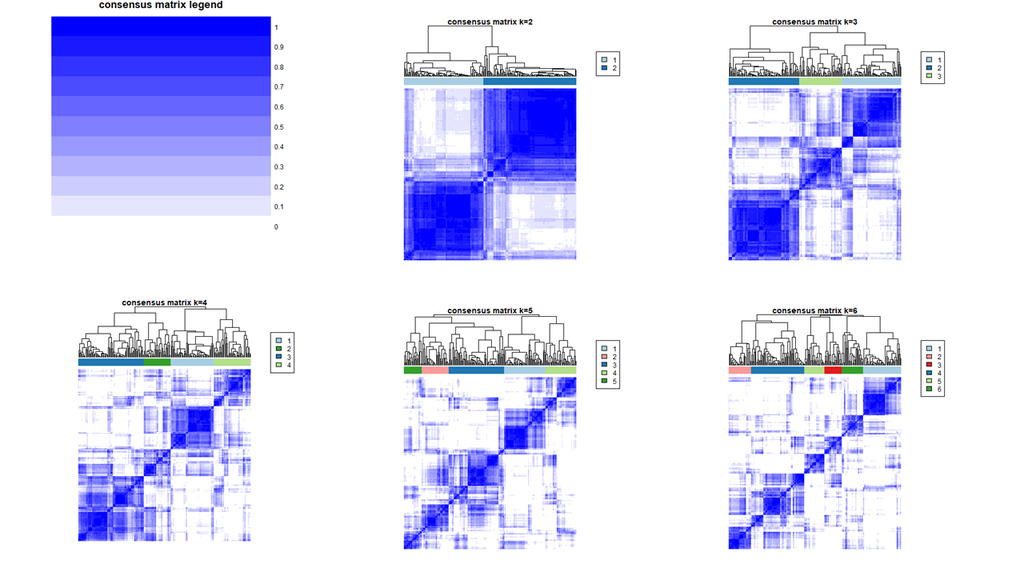

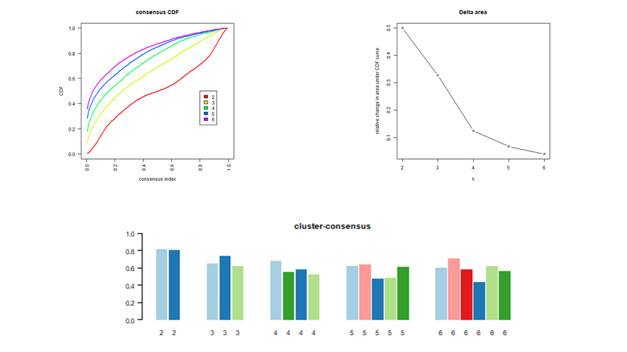

```r
data3.new<- t(scale(data3[,1:4],T,T))

results.dat3<-  ConsensusClusterPlus(as.matrix(data3.new),maxK=6,reps=1000,pItem=0.8,pFeature=1,
                               clusterAlg="km",distance="euclidean",seed=1262,plot='png',
                               title=paste0(path,'/hydapDat3'))

#results2.dat3<- calcICL(results.dat3, plot='png',title=paste0(path,'/hydapDat3'))
```

#### From consensus k-means results of data 3, we can observe that none of these numbers is the optimal number of clusters. Therefore, Data 3 is defined as *homogeneous cluster structure* and all continuous variables will be dropped in final clustering.

```r
cramer.v(table(data3$x5,data3$x6))
```

```
## [1] 0.09764819
```

```r
cramer.v(table(data3$x5,data3$x7))
```

```
## [1] 0.6758128
```

```r
cramer.v(table(data3$x6,data3$x7))
```

```
## [1] 0.1005522
```

#### Based on the pair-wise cramer's V between categorical variables, $x_6$ will be dropped in final clustering.

## Step 2 Final Clustering

```r
true_c<- c(rep(1,40),rep(2,40),rep(3,120))

hydap.dat1<- hydap(data=data1[,c(1:3,5)],conti.pos = 1:3,cate.pos = 4,k=3)

adjustedRandIndex(true_c,hydap.dat1$clustering)
```

```
## [1] 0.9676672
```

```r
hydap.dat2<- hydap(data=data2[,c(1:11,13,14)],conti.pos = 1:11,cate.pos = 12:13,k=3)

adjustedRandIndex(true_c,hydap.dat2$clustering)
```

```
## [1] 0.9677997
```

```r
hydap.dat3<- hydap(data=data3[,c(5,7)],conti.pos = NULL,cate.pos = 4,k=3)

adjustedRandIndex(true_c,hydap.dat3$clustering)
```

```
## [1] 0.7293102
```